# Healthcare diabetic project

### Context

> This dataset is originally from the National Institute of Diabetes and Digestive and Kidney Diseases. The objective of the dataset is to diagnostically predict whether or not a patient has diabetes, based on certain diagnostic measurements included in the dataset. Several constraints were placed on the selection of these instances from a larger database. In particular, all patients here are females at least 21 years old of Pima Indian heritage.

### Problem Statement

> Build a model to accurately predict whether the patients in the dataset have diabetes or not?

### Dataset Description:

> The datasets consists of several medical predictor variables and one target variable, Outcome. Predictor variables includes the number of pregnancies the patient has had, their BMI, insulin level, age, and so on.
1. Pregnancies: Number of times pregnant
2. Glucose: Plasma glucose concentration a 2 hours in an oral glucose tolerance test
3. BloodPressure: Diastolic blood pressure (mm Hg)
4. SkinThickness: Triceps skin fold thickness (mm)
5. Insulin: 2-Hour serum insulin (mu U/ml)
6. BMI: Body mass index (weight in kg/(height in m)^2)
7. DiabetesPedigreeFunction: Diabetes pedigree function
8. Age: Age (years)
9. Outcome: Class variable (0 or 1) 268 of 768 are 1, the others are 0

## Week 1 Tasks:

> Descriptive Analysis 1. It is very important to understand the variables and corresponding values. We need to think through - Can minimum value of below listed columns be zero (0)? On these columns, a value of zero does not make sense and thus indicates missing value.
1. Glucose
2. Bloodpressure
3. SkinThickness
4. Insulin
5. BMI

> 2.Visually explore these variable, I need to look for the distribution of these variables using histograms.

> Observe integer as well as float data-type of variables in this dataset. Create a count (frequency) plot describing the data types and the count of variables.

### Code:

```python
import numpy as np
import pandas as pd
import  matplotlib.pyplot  as plt
import seaborn as sns
```

```python
dataset = pd.read_csv("health care diabetes.csv")
```

```python
dataset.head()
```

|  | Pregnancies | Glucose | BloodPressure | SkinThickness | Insulin | BMI | DiabetesPedigreeFunction | Age | Outcome |
| --- | --- | --- | --- | --- | --- | --- | --- | --- | --- |
| 0 | 6 | 148 | 72 | 35 | 0 | 33.6 | 0.627 | 50 | 1 |
| 1 | 1 | 85 | 66 | 29 | 0 | 26.6 | 0.351 | 31 | 0 |
| 2 | 8 | 183 | 64 | 0 | 0 | 23.3 | 0.672 | 32 | 1 |
| 3 | 1 | 89 | 66 | 23 | 94 | 28.1 | 0.167 | 21 | 0 |
| 4 | 0 | 137 | 40 | 35 | 168 | 43.1 | 2.288 | 33 | 1 |

```python
dataset.isna().sum()
```

```
Pregnancies                 0
Glucose                     0
BloodPressure               0
SkinThickness               0
Insulin                     0
BMI                         0
DiabetesPedigreeFunction    0
Age                         0
Outcome                     0
dtype: int64
```

# No missing values in the dataset

```python
dataset['Outcome'].value_counts()
```

```
0    500
1    268
Name: Outcome, dtype: int64
```

# Data is Biased

1. **We need to resolve the biasness of data**

### Outcome data is skewed data

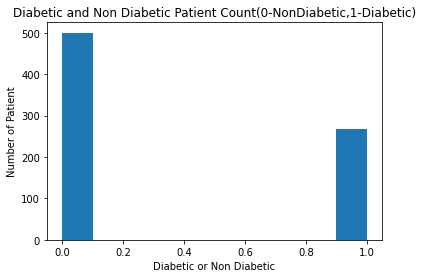

```python
plt.hist(dataset['Outcome'])
plt.ylabel("Number of Patient")
plt.xlabel("Diabetic or Non Diabetic")
plt.title("Diabetic and Non Diabetic Patient Count(0-NonDiabetic,1-Diabetic)");
```

```python
from PIL import Image as PILImage
import base64, io, IPython
def image_import(image):
    image = PILImage.open(image)
    output = io.BytesIO()
    image.save(output, format='PNG')
    encoded_string = base64.b64encode(output.getvalue()).decode()
    html = '<img src="data:…"/>'.format(encoded_string)
    return IPython.display.HTML(html)
```

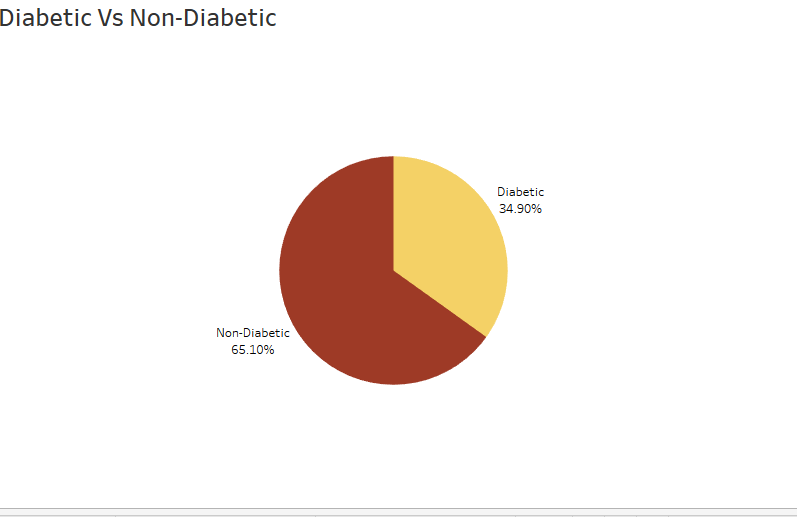

```python
image_import('Pie_chart.png')
```

[Click here](https://public.tableau.com/profile/mayank.mishra4078#!/vizhome/NIDK_dataset/CorrelationBetweenAgeandPregnancis?publish=yes) for detail Dashboard

## Outliers Analysis

#### I checked the boxplot for checking all the outliers

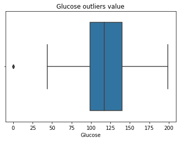

```python
sns.boxplot(dataset['Glucose']);
plt.title("Glucose outliers value");
```

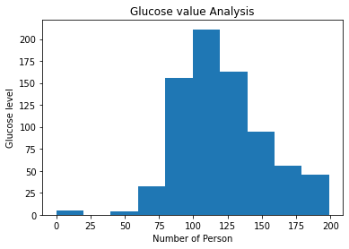

```python
plt.hist(dataset['Glucose']);
plt.xlabel("Number of Person")
plt.ylabel("Glucose level")
plt.title("Glucose value Analysis");
```

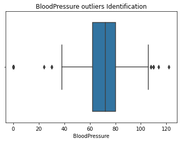

```python
sns.boxplot(dataset['BloodPressure']);
plt.title("BloodPressure outliers Identification");
```

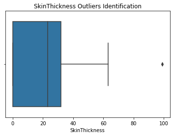

```python
sns.boxplot(dataset['SkinThickness']);
plt.title("SkinThickness Outliers Identification");
```

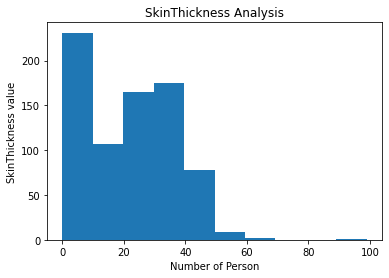

```python
plt.hist(dataset['SkinThickness']);
plt.xlabel("Number of Person")
plt.ylabel("SkinThickness value")
plt.title("SkinThickness Analysis");
```

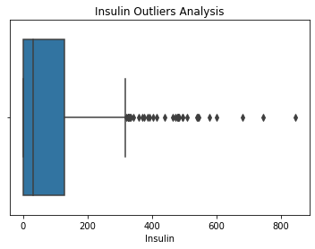

```python
sns.boxplot(dataset['Insulin']);
plt.title("Insulin Outliers Analysis");
```

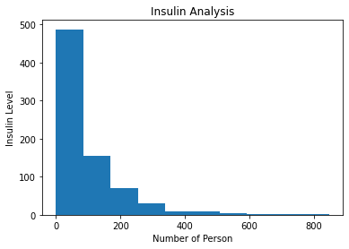

```python
plt.hist(dataset['Insulin']);
plt.xlabel("Number of Person")
plt.ylabel("Insulin Level")
plt.title("Insulin Analysis");
```

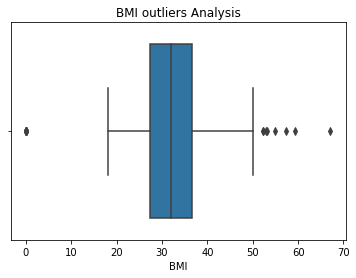

```python
sns.boxplot(dataset['BMI']);
plt.title("BMI outliers Analysis");
```

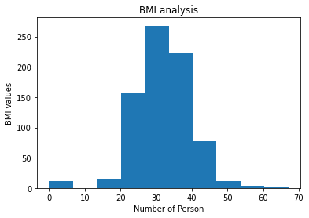

```python
plt.hist(dataset['BMI']);
plt.xlabel("Number of Person")
plt.ylabel("BMI values")
plt.title("BMI analysis");
```

```python
dataset['Glucose'].isin([0]).sum()
```

```
5
```

```python
mean_data_glucose = dataset['Glucose'].mean(skipna = True)
```

```python
mean_data_glucose
```

```
120.89453125
```

```python
max(dataset['Glucose'])
```

```
199
```

```python
dataset['Glucose']=dataset.replace(0,mean_data_glucose)
```

```python
dataset['Glucose'].isin([0]).sum()
```

```
0
```

## Now I am replacing all others with the median

1. **The Reason I am replacing BMI,Bloodsugar,skinthickness with median becuase it has a outliers which can affect the mean value.**

```python
dataset['BloodPressure'].isin([0]).sum()
```

```
35
```

```python
median_data_bloodpressure = dataset["BloodPressure"].median(skipna= True)
median_data_bloodpressure
```

```
72.0
```

```python
dataset['BloodPressure']=dataset['BloodPressure'].replace(0,median_data_bloodpressure)
```

```python
dataset['BloodPressure'].isin([0]).sum()
```

```
0
```

```python
def median_replace(dataset_1):
    median_data = dataset_1.median(skipna=True)
    dataset_1_upd = dataset_1.replace(0,median_data)
    return dataset_1_upd
```

```python
dataset['SkinThickness']=median_replace(dataset['SkinThickness'])
```

```python
dataset['SkinThickness'].isin([0]).sum()
```

```
0
```

```python
dataset['Insulin'].isin([0]).sum()
```

```
374
```

```python
dataset['Insulin']=median_replace(dataset["Insulin"])
```

```python
dataset['Insulin'].isin([0]).sum()
```

```
0
```

```python
dataset['BMI'].isin([0]).sum()
```

```
11
```

```python
dataset['BMI'] = median_replace(dataset["BMI"])
```

```python
dataset['BMI'].isin([0]).sum()
```

```
0
```

```python
dataset.head()
```

|  | Pregnancies | Glucose | BloodPressure | SkinThickness | Insulin | BMI | DiabetesPedigreeFunction | Age | Outcome |
| --- | --- | --- | --- | --- | --- | --- | --- | --- | --- |
| 0 | 6 | 6.000000 | 72 | 35 | 30.5 | 33.6 | 0.627 | 50 | 1 |
| 1 | 1 | 1.000000 | 66 | 29 | 30.5 | 26.6 | 0.351 | 31 | 0 |
| 2 | 8 | 8.000000 | 64 | 23 | 30.5 | 23.3 | 0.672 | 32 | 1 |
| 3 | 1 | 1.000000 | 66 | 23 | 94.0 | 28.1 | 0.167 | 21 | 0 |
| 4 | 0 | 120.894531 | 40 | 35 | 168.0 | 43.1 | 2.288 | 33 | 1 |

```python
type(dataset["Pregnancies"])
```

```
pandas.core.series.Series
```

```python
def cnt_int_flat(data_1):
    data_type = None

    for value in data_1:
        if value%1==0:
            data_type="Int"
            print(data_type)


        else:
            data_type="Float"
            print(data_type)
```

```python
dataset["BMI"].count()
```

```
768
```

```python
integer_count_BMI = 0
float_count_BMI = 0

for value in dataset["BMI"]:
    if value%1==0:
        integer_count_BMI +=1

    else:
        float_count_BMI +=1

print("intger_count:{} and float_count:{}".format(integer_count_BMI,float_count_BMI))
```

```
intger_count:92 and float_count:676
```

```python
integer_count_BP = 0
float_count_BP = 0
for value in dataset["BloodPressure"]:
    if value%1==0:
        integer_count_BP +=1
    else:
        float_count_BP +=1
print("intger_count:{} and float_count:{}".format(integer_count_BP,float_count_BP))
```

```
intger_count:768 and float_count:0
```

```python
integer_count_pregnancies = 0
float_count_pregnancies = 0
for value in dataset["Pregnancies"]:
    if value%1==0:
        integer_count_pregnancies +=1
    else:
        float_count_pregnancies +=1
print("intger_count:{} and float_count:{}".format(integer_count_pregnancies,float_count_pregnancies))
```

```
intger_count:768 and float_count:0
```

```python
integer_count_SkinThickness = 0
float_count_SkinThickness = 0
for value in dataset["SkinThickness"]:
    if value%1==0:
        integer_count_SkinThickness +=1
    else:
        float_count_SkinThickness +=1
print("intger_count:{} and float_count:{}".format(integer_count_SkinThickness,float_count_SkinThickness))
```

```
intger_count:768 and float_count:0
```

```python
integer_count_Insulin= 0
float_count_Insulin = 0
for value in dataset["Insulin"]:
    if value%1==0:
        integer_count_Insulin +=1
    else:
        float_count_Insulin +=1
print("intger_count:{} and float_count:{}".format(integer_count_Insulin,float_count_Insulin))
```

```
intger_count:394 and float_count:374
```

```python
integer_count_Glucose= 0
float_count_Glucose = 0
for value in dataset["Glucose"]:
    if value%1==0:
        integer_count_Glucose +=1
    else:
        float_count_Glucose +=1
print("intger_count:{} and float_count:{}".format(integer_count_Glucose,float_count_Glucose))
```

```
intger_count:657 and float_count:111
```

```python
integer_count_DiabetesPedigreeFunction= 0
float_count_DiabetesPedigreeFunction = 0
for value in dataset["DiabetesPedigreeFunction"]:
    if value%1==0:
        integer_count_DiabetesPedigreeFunction +=1
    else:
        float_count_DiabetesPedigreeFunction +=1
print("intger_count:{} and float_count:{}".format(integer_count_DiabetesPedigreeFunction,float_count_DiabetesPedigreeFunction))
```

```
intger_count:0 and float_count:768
```

```python
dictionary_float_int ={"Float":[float_count_BMI,float_count_pregnancies,float_count_BP,float_count_SkinThickness,float_count_Insulin,float_count_Glucose,float_count_DiabetesPedigreeFunction],"Int":[integer_count_BMI,integer_count_pregnancies,integer_count_BP,integer_count_SkinThickness,integer_count_Insulin,integer_count_Glucose,integer_count_DiabetesPedigreeFunction]}
df_BMI = pd.DataFrame(dictionary_float_int,index=["BMI","BP","Pregnancies","SkinThickness","Insulin","Glucose","DiabetesPedigreeFunction"])

df_BMI
```

|  | Float | Int |
| --- | --- | --- |
| BMI | 676 | 92 |
| BP | 0 | 768 |
| Pregnancies | 0 | 768 |
| SkinThickness | 0 | 768 |
| Insulin | 374 | 394 |
| Glucose | 111 | 657 |
| DiabetesPedigreeFunction | 768 | 0 |

## All the columns with their float and Integer data type values

### Visualization of all the data type with respect to the columns

```python
dataset_BMI_FLT_int = np.where(dataset['BMI']%1==0,"Int","Float")
```

```python
type(dataset_BMI_FLT_int)
```

```
numpy.ndarray
```

```python
dataset_BMI_datatype_count = pd.DataFrame(dataset_BMI_FLT_int,columns=['Count'])
```

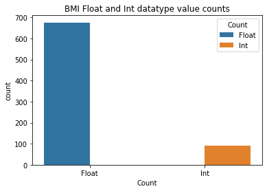

```python
sns.countplot(x = "Count",data=dataset_BMI_datatype_count,hue="Count");
plt.title("BMI Float and Int datatype value counts");
```

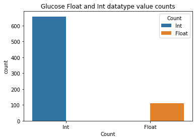

```python
dataset_Glucose_FLT_int = np.where(dataset['Glucose']%1==0,"Int","Float")
dataset_Glucose_datatype_count = pd.DataFrame(dataset_Glucose_FLT_int,columns=['Count'])

sns.countplot(x = "Count",data=dataset_Glucose_datatype_count,hue="Count");
plt.title("Glucose Float and Int datatype value counts");
```

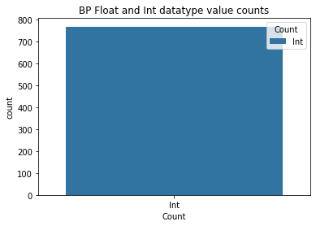

```python
dataset_BloodPressure_FLT_int = np.where(dataset['BloodPressure']%1==0,"Int","Float")
dataset_BloodPressure_datatype_count = pd.DataFrame(dataset_BloodPressure_FLT_int,columns=['Count'])

sns.countplot(x = "Count",data=dataset_BloodPressure_datatype_count,hue = "Count")
plt.title("BP Float and Int datatype value counts");
```

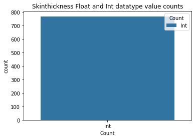

```python
dataset_SkinThickness_FLT_int = np.where(dataset['SkinThickness']%1==0,"Int","Float")
dataset_SkinThickness_datatype_count = pd.DataFrame(dataset_BloodPressure_FLT_int,columns=['Count'])

sns.countplot(x = "Count",data=dataset_SkinThickness_datatype_count,hue="Count")
plt.title("Skinthickness Float and Int datatype value counts");
```

[figure not shown]

```python
dataset_Insulin_FLT_int = np.where(dataset['Insulin']%1==0,"Int","Float")
dataset_Insulin_datatype_count = pd.DataFrame(dataset_BloodPressure_FLT_int,columns=['Count'])

sns.countplot(x = "Count",data=dataset_Insulin_datatype_count,hue="Count")
plt.title("Insulin Float and Int datatype value counts");
```

# Three parts are completed

## Week 1 task completed

# Week 2 task

### Task1

##### 1. Check the balance of the data by plotting the count of outcomes by their value. Describe your findings and plan future course of actions.

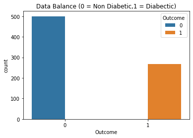

```python
sns.countplot(x = "Outcome",data=dataset,hue="Outcome")
plt.title("Data Balance (0 = Non Diabetic,1 = Diabectic)");
```

## Week 2 task 2

**Scatter charts between the pair of variables to understand the relationships.**

```python
dataset.head()
```

|  | Pregnancies | Glucose | BloodPressure | SkinThickness | Insulin | BMI | DiabetesPedigreeFunction | Age | Outcome |
| --- | --- | --- | --- | --- | --- | --- | --- | --- | --- |
| 0 | 6 | 6.000000 | 72 | 35 | 30.5 | 33.6 | 0.627 | 50 | 1 |
| 1 | 1 | 1.000000 | 66 | 29 | 30.5 | 26.6 | 0.351 | 31 | 0 |
| 2 | 8 | 8.000000 | 64 | 23 | 30.5 | 23.3 | 0.672 | 32 | 1 |
| 3 | 1 | 1.000000 | 66 | 23 | 94.0 | 28.1 | 0.167 | 21 | 0 |
| 4 | 0 | 120.894531 | 40 | 35 | 168.0 | 43.1 | 2.288 | 33 | 1 |

### Plotting the scatter chart b\w Pregnancies and Glucose

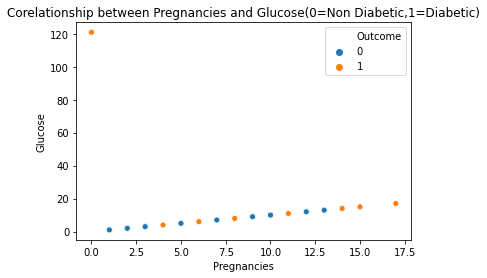

```python
#Plot

sns.scatterplot(x="Pregnancies",y="Glucose",hue="Outcome",data=dataset)
plt.title("Corelationship between Pregnancies and Glucose(0=Non Diabetic,1=Diabetic)");
```

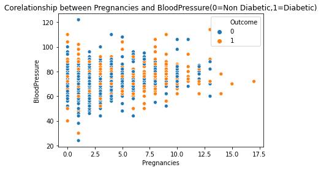

```python
sns.scatterplot(x="Pregnancies",y="BloodPressure",hue="Outcome",data=dataset)
plt.title("Corelationship between Pregnancies and BloodPressure(0=Non Diabetic,1=Diabetic)");
```

Pregnancies and Bloodpressure has non linear relationship but **high bloodpressure (>80mmHg)** and **Pregnancies over (>7) may cost the diabetes**

### Pregnancies Vs SkinThickness

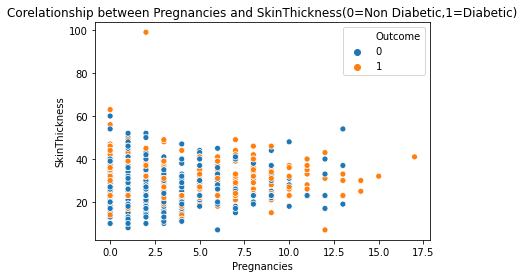

```python
sns.scatterplot(x="Pregnancies",y="SkinThickness",hue="Outcome",data=dataset)
plt.title("Corelationship between Pregnancies and SkinThickness(0=Non Diabetic,1=Diabetic)");
```

SkinThickness and Pregnancies has non linear relationship. Skinthickness and Pregnancies are not changing with each other linearly but patteren for diabetes is showing **pregnancies over (>7)** and Skinthickness in **range of 30 to 60 can have more chances of diabetes**

### Pregnancies Vs Insulin

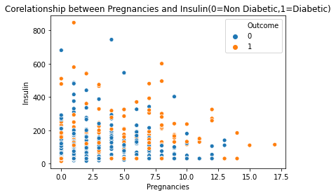

```python
sns.scatterplot(x="Pregnancies",y="Insulin",hue="Outcome",data=dataset)
plt.title("Corelationship between Pregnancies and Insulin(0=Non Diabetic,1=Diabetic)");
```

*Insulin:-Insulin is peptide homorone produced by beta cells of the pancreatic islets .Work of a Insulin is to regulte the glucose in the blood*.

Relationship between Insulin and Pregnancies are not highly correlated .Alone Insulin is not able to predict the diabetes but patteren is saying **insulin level over (>200)** and **Pregnancies over(>7)** may have chance of diabetes.

### Pregnancies Vs BMI

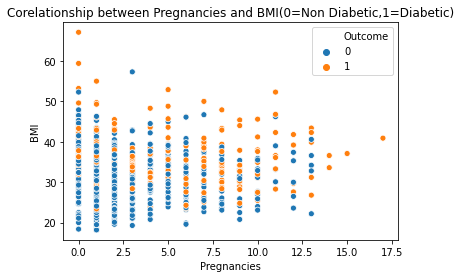

```python
sns.scatterplot(x="Pregnancies",y="BMI",hue="Outcome",data=dataset)
plt.title("Corelationship between Pregnancies and BMI(0=Non Diabetic,1=Diabetic)");
```

**Pregnancies and BMI has non linear relationship they are not highly correlated but as per patteren high BMI may cause the diabetes**

### Pregnancies vs DiabetesPedigreeFunction

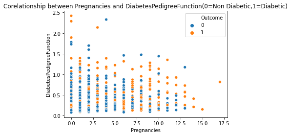

```python
sns.scatterplot(x="Pregnancies",y="DiabetesPedigreeFunction",hue="Outcome",data=dataset)
plt.title("Corelationship between Pregnancies and DiabetesPedigreeFunction(0=Non Diabetic,1=Diabetic)");
```

*DiabetesPedigreeFunction:- DiabetesPedigreeFunction provides us the informtion about the patient which have diabetes in their ancestor and which pass through the genes to other generation*

**Pregnancies and DiabetesPedigreeFunction has non linear and not highly correlated but high DiabetesPedigreeFunction has more chance of Diabetes .**

### Preganancies vs Age

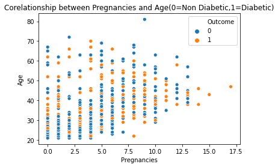

```python
sns.scatterplot(x="Pregnancies",y="Age",hue="Outcome",data=dataset)
plt.title("Corelationship between Pregnancies and Age(0=Non Diabetic,1=Diabetic)");
```

Pregnancies and Age has correlated to each other.We can say that on the inside information from this chart is the persons **age over (>30)** may more chances of diabetes.

### Glucose vs BloodPressure

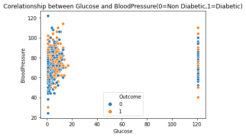

```python
sns.scatterplot(x="Glucose",y="BloodPressure",hue="Outcome",data=dataset)
plt.title("Corelationship between Glucose and BloodPressure(0=Non Diabetic,1=Diabetic)");
```

**Glucose and Bloodpressure are not highly correlated to each other and no specific patteren between Blood Pressure and Diabetes.**

### Glucose vs SkinThickness

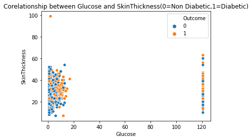

```python
sns.scatterplot(x="Glucose",y="SkinThickness",hue="Outcome",data=dataset)
plt.title("Corelationship between Glucose and SkinThickness(0=Non Diabetic,1=Diabetic)");
```

SkinThickness and Glucose are not dependent to each other.In the patteren it is showing that **SkinThickness between 20-40 may have more chances of diabetes**.

### Glucose vs Insulin

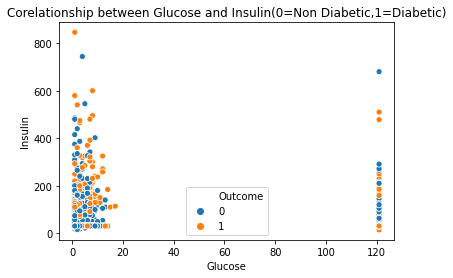

```python
sns.scatterplot(x="Glucose",y="Insulin",hue="Outcome",data=dataset)
plt.title("Corelationship between Glucose and Insulin(0=Non Diabetic,1=Diabetic)");
```

**Comment:-Insulin and Glucose are not highly correlated but High Insulin level may cause the Diabetes.**

### Glucose vs BMI

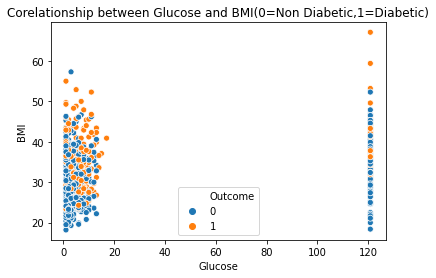

```python
sns.scatterplot(x="Glucose",y="BMI",hue="Outcome",data=dataset)
plt.title("Corelationship between Glucose and BMI(0=Non Diabetic,1=Diabetic)");
```

**Glucose and BMI are not Highly correlated but with the patteren it is clear that high BMI may cause the diabetes.**

### Glucose vs DiabetesPedigreeFunction

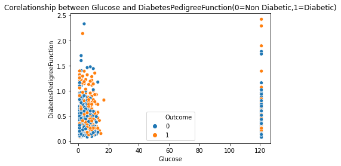

```python
sns.scatterplot(x="Glucose",y="DiabetesPedigreeFunction",hue="Outcome",data=dataset)
plt.title("Corelationship between Glucose and DiabetesPedigreeFunction(0=Non Diabetic,1=Diabetic)");
```

**Comment:-Glucose and DiabetesPedigreeFunction are not dependent to each other but with the patteren we can conclude that if person have high value DiabetesPedigreeFunction it mayincrease the chances of Diabetes.**

### Glucose vs Age

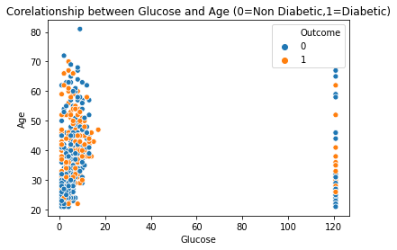

```python
sns.scatterplot(x="Glucose",y="Age",hue="Outcome",data=dataset)
plt.title("Corelationship between Glucose and Age (0=Non Diabetic,1=Diabetic)");
```

### Checking **Top 5** rows

```python
dataset.head()
```

|  | Pregnancies | Glucose | BloodPressure | SkinThickness | Insulin | BMI | DiabetesPedigreeFunction | Age | Outcome |
| --- | --- | --- | --- | --- | --- | --- | --- | --- | --- |
| 0 | 6 | 6.000000 | 72 | 35 | 30.5 | 33.6 | 0.627 | 50 | 1 |
| 1 | 1 | 1.000000 | 66 | 29 | 30.5 | 26.6 | 0.351 | 31 | 0 |
| 2 | 8 | 8.000000 | 64 | 23 | 30.5 | 23.3 | 0.672 | 32 | 1 |
| 3 | 1 | 1.000000 | 66 | 23 | 94.0 | 28.1 | 0.167 | 21 | 0 |
| 4 | 0 | 120.894531 | 40 | 35 | 168.0 | 43.1 | 2.288 | 33 | 1 |

### Scatter chart between **BloodPressure vs SkinThickness**

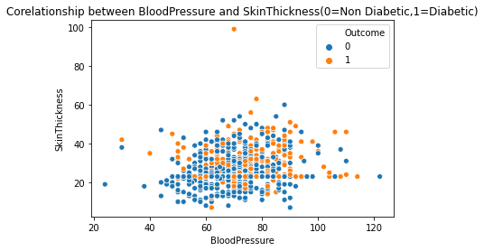

```python
sns.scatterplot(x="BloodPressure",y="SkinThickness",hue="Outcome",data=dataset)
plt.title("Corelationship between BloodPressure and SkinThickness(0=Non Diabetic,1=Diabetic)");
```

**Bloodpressure and skinthickness are positively correlated to each other but not very stongly with the above patteren we can say that highblood pressure and high SkinThicness may cause the Diabetes**

### Scatter Chart between **BloodPressure vs Insulin**

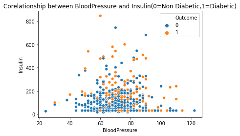

```python
sns.scatterplot(x="BloodPressure",y="Insulin",hue="Outcome",data=dataset)
plt.title("Corelationship between BloodPressure and Insulin(0=Non Diabetic,1=Diabetic)");
```

### Scatter chart between **BloodPressure vs BMI**

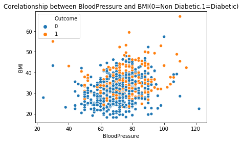

```python
sns.scatterplot(x="BloodPressure",y="BMI",hue="Outcome",data=dataset)
plt.title("Corelationship between BloodPressure and BMI(0=Non Diabetic,1=Diabetic)");
```

**BMI and BloodPressure are dependent to each other with the high bloodPressure and BMI chances of Diabetes are more.**

### Scatter Chart Between **BloodPressure vs DiabetesPedigreeFunction**

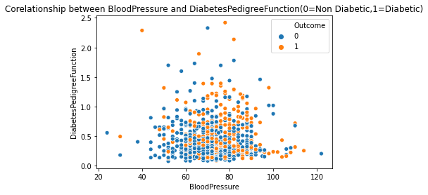

```python
sns.scatterplot(x="BloodPressure",y="DiabetesPedigreeFunction",hue="Outcome",data=dataset)
plt.title("Corelationship between BloodPressure and DiabetesPedigreeFunction(0=Non Diabetic,1=Diabetic)");
```

**BloodPressure and DiabeticPedigreeFunction are not highly correlated with each other**

### Analysis between BloodPressure vs Age

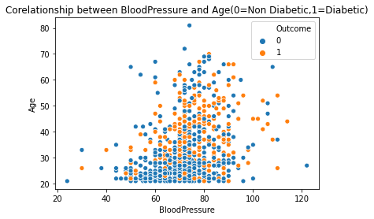

```python
sns.scatterplot(x="BloodPressure",y="Age",hue="Outcome",data=dataset)
plt.title("Corelationship between BloodPressure and Age(0=Non Diabetic,1=Diabetic)");
```

**BloodPressure and Age are not highly correlated with each other but with the above patteren we can say that older age person have more chances of diabetes than younger ones.**

```python
dataset.head()
```

|  | Pregnancies | Glucose | BloodPressure | SkinThickness | Insulin | BMI | DiabetesPedigreeFunction | Age | Outcome |
| --- | --- | --- | --- | --- | --- | --- | --- | --- | --- |
| 0 | 6 | 6.000000 | 72 | 35 | 30.5 | 33.6 | 0.627 | 50 | 1 |
| 1 | 1 | 1.000000 | 66 | 29 | 30.5 | 26.6 | 0.351 | 31 | 0 |
| 2 | 8 | 8.000000 | 64 | 23 | 30.5 | 23.3 | 0.672 | 32 | 1 |
| 3 | 1 | 1.000000 | 66 | 23 | 94.0 | 28.1 | 0.167 | 21 | 0 |
| 4 | 0 | 120.894531 | 40 | 35 | 168.0 | 43.1 | 2.288 | 33 | 1 |

### Scatter Chart between **SkinThickness vs Insulin**

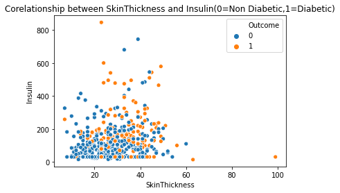

```python
sns.scatterplot(x="SkinThickness",y="Insulin",hue="Outcome",data=dataset)
plt.title("Corelationship between SkinThickness and Insulin(0=Non Diabetic,1=Diabetic)");
```

**SkinThickness and Insulin are positively correlated to each other.**

### SkinThickness vs BMI

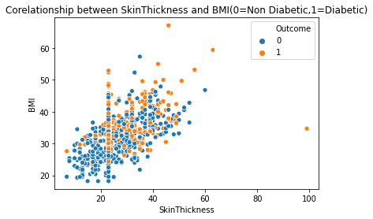

```python
sns.scatterplot(x="SkinThickness",y="BMI",hue="Outcome",data=dataset)
plt.title("Corelationship between SkinThickness and BMI(0=Non Diabetic,1=Diabetic)");
```

**BMI and SkinThickness are correlated to each other with the High BMI and High SkinThickness chances are more that person may have diabetes.**

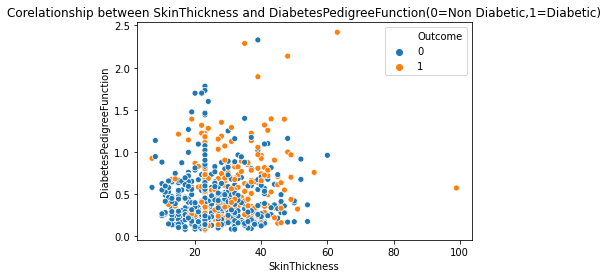

```python
sns.scatterplot(x="SkinThickness",y="DiabetesPedigreeFunction",hue="Outcome",data=dataset)
plt.title("Corelationship between SkinThickness and DiabetesPedigreeFunction(0=Non Diabetic,1=Diabetic)");
```

## skinthickness vs age

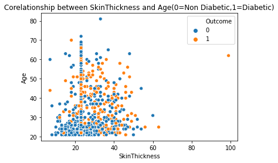

```python
sns.scatterplot(x="SkinThickness",y="Age",hue="Outcome",data=dataset)
plt.title("Corelationship between SkinThickness and Age(0=Non Diabetic,1=Diabetic)");
```

**SkinThickness and age are not strongly correlated with each other**

```python
dataset.head()
```

|  | Pregnancies | Glucose | BloodPressure | SkinThickness | Insulin | BMI | DiabetesPedigreeFunction | Age | Outcome |
| --- | --- | --- | --- | --- | --- | --- | --- | --- | --- |
| 0 | 6 | 6.000000 | 72 | 35 | 30.5 | 33.6 | 0.627 | 50 | 1 |
| 1 | 1 | 1.000000 | 66 | 29 | 30.5 | 26.6 | 0.351 | 31 | 0 |
| 2 | 8 | 8.000000 | 64 | 23 | 30.5 | 23.3 | 0.672 | 32 | 1 |
| 3 | 1 | 1.000000 | 66 | 23 | 94.0 | 28.1 | 0.167 | 21 | 0 |
| 4 | 0 | 120.894531 | 40 | 35 | 168.0 | 43.1 | 2.288 | 33 | 1 |

## Insulin vs BMI

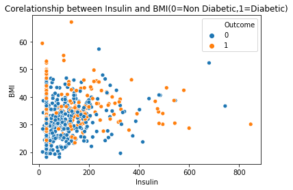

```python
sns.scatterplot(x="Insulin",y="BMI",hue="Outcome",data=dataset)
plt.title("Corelationship between Insulin and BMI(0=Non Diabetic,1=Diabetic)");
```

**Insulin and BMI are not strongly correlated with each other but high insulin level may cause the Diabetes**

## Insulin vs Diabetespedigree function

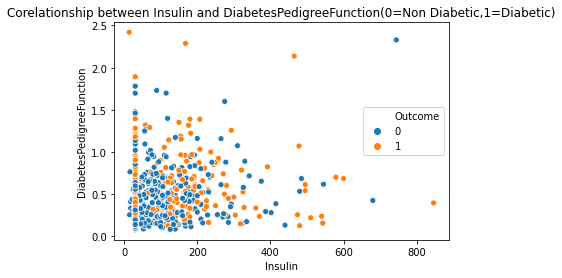

```python
sns.scatterplot(x="Insulin",y="DiabetesPedigreeFunction",hue="Outcome",data=dataset)
plt.title("Corelationship between Insulin and DiabetesPedigreeFunction(0=Non Diabetic,1=Diabetic)");
```

# Insulin and DiabetesePedigreeFunction are Positively correlated with each other high Insulin level may cause the Diabetes

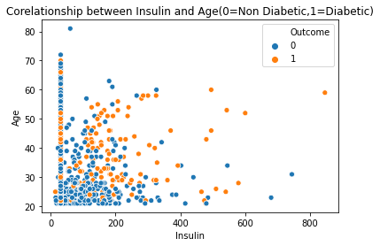

```python
sns.scatterplot(x="Insulin",y="Age",hue="Outcome",data=dataset)
plt.title("Corelationship between Insulin and Age(0=Non Diabetic,1=Diabetic)");
```

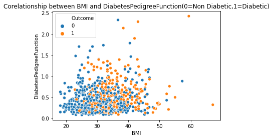

```python
sns.scatterplot(x="BMI",y="DiabetesPedigreeFunction",hue="Outcome",data=dataset)
plt.title("Corelationship between BMI and DiabetesPedigreeFunction(0=Non Diabetic,1=Diabetic)");
```

**BMI and DiabetesPedigree Function are positively Correlated to each Other but not very strongly with each Other**

```python
dataset.head()
```

|  | Pregnancies | Glucose | BloodPressure | SkinThickness | Insulin | BMI | DiabetesPedigreeFunction | Age | Outcome |
| --- | --- | --- | --- | --- | --- | --- | --- | --- | --- |
| 0 | 6 | 6.000000 | 72 | 35 | 30.5 | 33.6 | 0.627 | 50 | 1 |
| 1 | 1 | 1.000000 | 66 | 29 | 30.5 | 26.6 | 0.351 | 31 | 0 |
| 2 | 8 | 8.000000 | 64 | 23 | 30.5 | 23.3 | 0.672 | 32 | 1 |
| 3 | 1 | 1.000000 | 66 | 23 | 94.0 | 28.1 | 0.167 | 21 | 0 |
| 4 | 0 | 120.894531 | 40 | 35 | 168.0 | 43.1 | 2.288 | 33 | 1 |

# BMI VS AGE

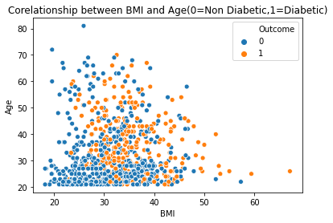

```python
sns.scatterplot(x="BMI",y="Age",hue="Outcome",data=dataset)
plt.title("Corelationship between BMI and Age(0=Non Diabetic,1=Diabetic)");
```

**BMI and Age are not correlated with each other.**

## Diabetespedigreefunction vs Age

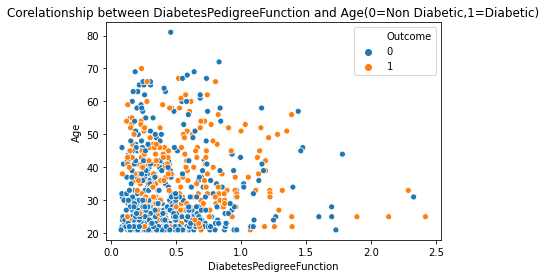

```python
sns.scatterplot(x="DiabetesPedigreeFunction",y="Age",hue="Outcome",data=dataset)
plt.title("Corelationship between DiabetesPedigreeFunction and Age(0=Non Diabetic,1=Diabetic)");
```

# DiabetesPedigree function and age are not strongly correlated both have positive correlation with each other but not very strongly bounded

### Conculsion:- We saw relationship between all the Features and some features are positively correlated and others are negatively but none of the features have very strong correlation that we can drop one column(we have less feature as well) data has little skewness due to outcome we need to remind this thing and we need 1-2 features as well becuase we are somewhere skiping the male for the data.

# Week 2 task 3

## Corelation matrix

1. correlation matrix tells us that relationship between the different objects
2. If two columns are heavily correlated to each other i.e they are depend upon each other
3. In calculation or model building we can drop the one of the columns.

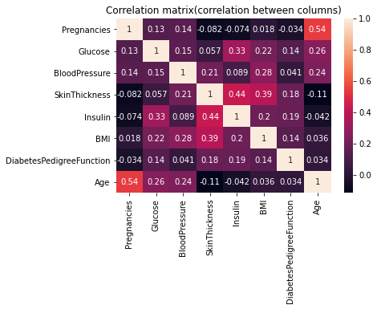

```python
correlation = dataset.iloc[:,:-1].corr()
sns.heatmap(correlation,annot=True);
plt.title("Correlation matrix(correlation between columns)");
```

# Week 2 taskcompleted

# Week 3 task

### Model Building and hypertunning

### Spliting the data(Dev/train or train/test)

### We can choose three path either we split the data in train / Test which is very old technique and in both the set ratio of diabetic or non diabetic should be same ,It is a easy technique we can use it less amount of data.

### Second Technique : In that scenario we split the data in 3 part dev/train/test dev part all non diabetic part +(1/2)*dibetic

```
              1. Train set : All non diabetic data(500)+(.50)*diabetic(134)
              2  Dev set:(1/4)*Diabetic data
              3. Test:(1/4)*Diabetic data
```

### Second approches requires lots of data for better result so we can use first approach

### Third approcahes we can use k crossvalidation set(Kfold validation) which will work will in this situation

### I will try first and third and comapre the result

# Spliting the data and Normalization

```python
X = dataset.iloc[:,:-1].values
y = dataset.iloc[:,-1].values
from sklearn.preprocessing import StandardScaler
Sc_X = StandardScaler()
X = Sc_X.fit_transform(X)
```

## First approach (Train-Test split)

```python
from sklearn.model_selection import train_test_split
X_train,X_test,y_train,y_test = train_test_split(X,y,test_size=0.3,stratify =y)
```

### Feature scaling for K_fold

```python
X_fold = dataset.iloc[:,:-1].values
y_fold = dataset.iloc[:,-1].values
from sklearn.preprocessing import StandardScaler
Sc_X_Fold = StandardScaler()
X_fold = Sc_X_Fold.fit_transform(X_fold)
```

### K Fold Cross validation Third approach

```python
from sklearn.model_selection import KFold
kf = KFold(n_splits = 7,random_state=42,shuffle=True)
for train_index, test_index in kf.split(X_fold):
    X_train_fold, X_test_fold = X_fold[train_index], X_fold[test_index]
    y_train_fold, y_test_fold = y_fold[train_index], y_fold[test_index]
```

## Model Creation

**The Problem is bascially a Classification problem.Different Classification Technique are as following:-***

```
      1. Logistic Regression
```

```
      2.Support Vector Machine (Kernal=Linear)
```

```
      3.Support Vector Machine(Krenal=rbf(non_linear))
```

```
       4.Naive Bayes
```

```
       5. K-Nearest Neighbours(KNN)
```

```
       6.Decision Tree classifier
```

```
        7.Random Forest Classifier
```

### We can use more powerful technique which is like gradientboosting and adaboosting but data is very small so the above mention methods are sufficient

# Logistic Regression

```python
from sklearn.linear_model import LogisticRegression
Classifier_logisticRegression = LogisticRegression(C=0.1,random_state=42)
Classifier_logisticRegression.fit(X_train,y_train)
```

```
LogisticRegression(C=0.1, class_weight=None, dual=False, fit_intercept=True,
                   intercept_scaling=1, l1_ratio=None, max_iter=100,
                   multi_class='auto', n_jobs=None, penalty='l2',
                   random_state=42, solver='lbfgs', tol=0.0001, verbose=0,
                   warm_start=False)
```

```python
y_pred = Classifier_logisticRegression.predict(X_test)
print(np.concatenate((y_pred.reshape(len(y_pred),1), y_test.reshape(len(y_test),1)),1))
```

```
[[0 0]
 [0 1]
 [0 0]
 [1 0]
 [0 0]
 [0 0]
 [0 1]
 [0 1]
 [0 1]
 [0 0]
 [0 0]
 [0 0]
 [1 1]
 [0 0]
 [0 0]
```

[output cut: 216 more lines]

```python
from sklearn.metrics import confusion_matrix
cm = confusion_matrix(y_test, y_pred)
print(cm)
```

```
[[133  17]
 [ 42  39]]
```

```python
from sklearn.metrics import precision_score,recall_score,f1_score,accuracy_score
accuracy_lr  = accuracy_score(y_test,y_pred)
precision = precision_score(y_test, y_pred)
recall = recall_score(y_test, y_pred)
F1_score1 = f1_score(y_test, y_pred)
print("Precision:{} and Recall:{} and F1_Score:{}".format(precision,recall,F1_score1))
```

```
Precision:0.6964285714285714 and Recall:0.48148148148148145 and F1_Score:0.5693430656934306
```

#### Hyperparameter Tunning

```python
param_grid1 = {
  'C': [0.01,0.1, 1, 10,100,1000]
}
from sklearn.model_selection import GridSearchCV
# Instantiate the grid search model
grid_search = GridSearchCV(estimator =Classifier_logisticRegression, param_grid = param_grid1)
```

```python
print(grid_search)
```

```
GridSearchCV(cv=None, error_score=nan,
             estimator=LogisticRegression(C=0.1, class_weight=None, dual=False,
                                          fit_intercept=True,
                                          intercept_scaling=1, l1_ratio=None,
                                          max_iter=100, multi_class='auto',
                                          n_jobs=None, penalty='l2',
                                          random_state=42, solver='lbfgs',
                                          tol=0.0001, verbose=0,
                                          warm_start=False),
             iid='deprecated', n_jobs=None,
             param_grid={'C': [0.01, 0.1, 1, 10, 100, 1000]},
             pre_dispatch='2*n_jobs', refit=True, return_train_score=False,
             scoring=None, verbose=0)
```

```python
grid_search.fit(X_train,y_train)
```

```
GridSearchCV(cv=None, error_score=nan,
             estimator=LogisticRegression(C=0.1, class_weight=None, dual=False,
                                          fit_intercept=True,
                                          intercept_scaling=1, l1_ratio=None,
                                          max_iter=100, multi_class='auto',
                                          n_jobs=None, penalty='l2',
                                          random_state=42, solver='lbfgs',
                                          tol=0.0001, verbose=0,
                                          warm_start=False),
             iid='deprecated', n_jobs=None,
             param_grid={'C': [0.01, 0.1, 1, 10, 100, 1000]},
             pre_dispatch='2*n_jobs', refit=True, return_train_score=False,
             scoring=None, verbose=0)
```

```python
print(grid_search.best_params_)
```

```
{'C': 0.01}
```

```python
param_grid2 = {
  'C': [0.1,0.2,0.3,0.5,0.6]
}
from sklearn.model_selection import GridSearchCV
# Instantiate the grid search model
grid_search2 = GridSearchCV(estimator =Classifier_logisticRegression, param_grid = param_grid2)
```

```python
grid_search2.fit(X_train,y_train)
```

```
GridSearchCV(cv=None, error_score=nan,
             estimator=LogisticRegression(C=0.1, class_weight=None, dual=False,
                                          fit_intercept=True,
                                          intercept_scaling=1, l1_ratio=None,
                                          max_iter=100, multi_class='auto',
                                          n_jobs=None, penalty='l2',
                                          random_state=42, solver='lbfgs',
                                          tol=0.0001, verbose=0,
                                          warm_start=False),
             iid='deprecated', n_jobs=None,
             param_grid={'C': [0.1, 0.2, 0.3, 0.5, 0.6]},
             pre_dispatch='2*n_jobs', refit=True, return_train_score=False,
             scoring=None, verbose=0)
```

```python
print(grid_search2.best_params_)
```

```
{'C': 0.1}
```

```python
final_logistic_regression =LogisticRegression(C=grid_search.best_params_['C'],penalty='l2',random_state=42)
final_logistic_regression.fit(X_train,y_train)
```

```
LogisticRegression(C=0.01, class_weight=None, dual=False, fit_intercept=True,
                   intercept_scaling=1, l1_ratio=None, max_iter=100,
                   multi_class='auto', n_jobs=None, penalty='l2',
                   random_state=42, solver='lbfgs', tol=0.0001, verbose=0,
                   warm_start=False)
```

```python
y_pred_final = final_logistic_regression.predict(X_test)
```

```python
from sklearn.metrics import confusion_matrix
cm_final_logisticregression= confusion_matrix(y_test,y_pred_final)
print(cm_final_logisticregression)
```

```
[[138  12]
 [ 52  29]]
```

```python
from sklearn.metrics import precision_score,recall_score,f1_score,accuracy_score
acc_lr = accuracy_score(y_test,y_pred_final)
precision = precision_score(y_test, y_pred_final)
recall = recall_score(y_test, y_pred_final)
F1_score1 = f1_score(y_test, y_pred_final)
print("Precision:{} and Recall:{} and F1_Score:{} and accuracy {}".format(precision,recall,F1_score1,acc_lr))
```

```
Precision:0.7073170731707317 and Recall:0.35802469135802467 and F1_Score:0.4754098360655737 and accuracy 0.7229437229437229
```

### No such Improvement in score after using gridsearch cv

## KNN algorithm for Train-test split

```python
from sklearn.neighbors import KNeighborsClassifier
Classifier_tt_KNN = KNeighborsClassifier()
Classifier_tt_KNN.fit(X_train,y_train)
```

```
KNeighborsClassifier(algorithm='auto', leaf_size=30, metric='minkowski',
                     metric_params=None, n_jobs=None, n_neighbors=5, p=2,
                     weights='uniform')
```

```python
y_pred_train_test_knn = Classifier_tt_KNN.predict(X_test)
```

```python
from sklearn.metrics import precision_score,recall_score,f1_score,accuracy_score,confusion_matrix
cm_knn = confusion_matrix(y_test,y_pred_train_test_knn)
acc_knn = accuracy_score(y_test,y_pred_train_test_knn)
precision_knn = precision_score(y_test, y_pred_train_test_knn)
recall_knn = recall_score(y_test, y_pred_train_test_knn)
F1_score1_knn = f1_score(y_test, y_pred_train_test_knn)
print(cm_knn)
print("Precision:{} and Recall:{} and F1_Score:{} and accuracy {}".format(precision_knn,recall_knn,F1_score1_knn,acc_knn))
```

```
[[117  33]
 [ 40  41]]
Precision:0.5540540540540541 and Recall:0.5061728395061729 and F1_Score:0.5290322580645161 and accuracy 0.683982683982684
```

## Randomforest classifier

```python
from sklearn.ensemble import RandomForestClassifier
Classifier_tt_rf =RandomForestClassifier(random_state=42)
Classifier_tt_rf.fit(X_train,y_train)
```

```
RandomForestClassifier(bootstrap=True, ccp_alpha=0.0, class_weight=None,
                       criterion='gini', max_depth=None, max_features='auto',
                       max_leaf_nodes=None, max_samples=None,
                       min_impurity_decrease=0.0, min_impurity_split=None,
                       min_samples_leaf=1, min_samples_split=2,
                       min_weight_fraction_leaf=0.0, n_estimators=100,
                       n_jobs=None, oob_score=False, random_state=42, verbose=0,
                       warm_start=False)
```

```python
y_pred_train_test_rf = Classifier_tt_rf.predict(X_test)
```

```python
from sklearn.metrics import precision_score,recall_score,f1_score,accuracy_score
acc_rf = accuracy_score(y_test,y_pred_train_test_rf)
precision_rf = precision_score(y_test, y_pred_train_test_rf)
recall_rf = recall_score(y_test, y_pred_train_test_rf)
F1_score1_rf = f1_score(y_test, y_pred_train_test_rf)
print("Precision:{} and Recall:{} and F1_Score:{} and accuracy {}".format(precision_rf,recall_rf,F1_score1_rf,acc_rf))
```

```
Precision:0.6417910447761194 and Recall:0.5308641975308642 and F1_Score:0.5810810810810811 and accuracy 0.7316017316017316
```

```python
Comaprison_dict_tt = {"Accuracy":[acc_lr,acc_knn,acc_rf],"Precision":[precision,precision_knn,precision_rf],"Recall":[recall,recall_knn,recall_rf],"F1_score":[F1_score1,F1_score1_knn,F1_score1_rf]}
Dataset_com_train_test = pd.DataFrame(Comaprison_dict_tt,index=['Logistic_regression','KNN','RF'])
Dataset_com_train_test
```

|  | Accuracy | Precision | Recall | F1_score |
| --- | --- | --- | --- | --- |
| Logistic_regression | 0.722944 | 0.707317 | 0.358025 | 0.475410 |
| KNN | 0.683983 | 0.554054 | 0.506173 | 0.529032 |
| RF | 0.731602 | 0.641791 | 0.530864 | 0.581081 |

### It is the result of Train-Tset split(stratify y)

### k-fold cross validation

**K-fold is very useful when data is biased our o/p column is bias so we will check the result with k-fold**

# K Fold validation set for logistic Regression

```python
from sklearn.linear_model import LogisticRegression
Classifier_logisticRegression_fold = LogisticRegression(C=0.1,random_state=42)
Classifier_logisticRegression_fold.fit(X_train_fold,y_train_fold)
```

```
LogisticRegression(C=0.1, class_weight=None, dual=False, fit_intercept=True,
                   intercept_scaling=1, l1_ratio=None, max_iter=100,
                   multi_class='auto', n_jobs=None, penalty='l2',
                   random_state=42, solver='lbfgs', tol=0.0001, verbose=0,
                   warm_start=False)
```

```python
y_pred_fold = Classifier_logisticRegression_fold.predict(X_test_fold)
```

```python
from sklearn.metrics import confusion_matrix,precision_score,recall_score,f1_score,accuracy_score
cm_kfold_lr=confusion_matrix(y_pred_fold,y_test_fold)
acc_kfold_lr = accuracy_score(y_pred_fold,y_test_fold)
precision_kfold_lr =precision_score(y_pred_fold,y_test_fold)
recall_kfold_lr = recall_score(y_pred_fold,y_test_fold)
F1score_kfold_lr =f1_score(y_pred_fold,y_test_fold)
print(cm_kfold_lr)
print("Precission:{} and Recall:{} and F1score:{} and acc{}".format(precision_kfold_lr,recall_kfold_lr,F1score_kfold_lr,acc_kfold_lr))
```

```
[[56 28]
 [11 14]]
Precission:0.3333333333333333 and Recall:0.56 and F1score:0.41791044776119407 and acc0.6422018348623854
```